## BRC Census

# Event Logistics

## Ticket Source, Participant Expenses, Impacts on Nevada State, and Other Recreation

## Ticket Source

*The exact wording of this question has changed over the years, to match the ticket sale logistics for each given year. The bar plot directly below displays 2019 data, followed by a separate line plot with data from 2014 through 2019.*

# Burning Man Ticket Source

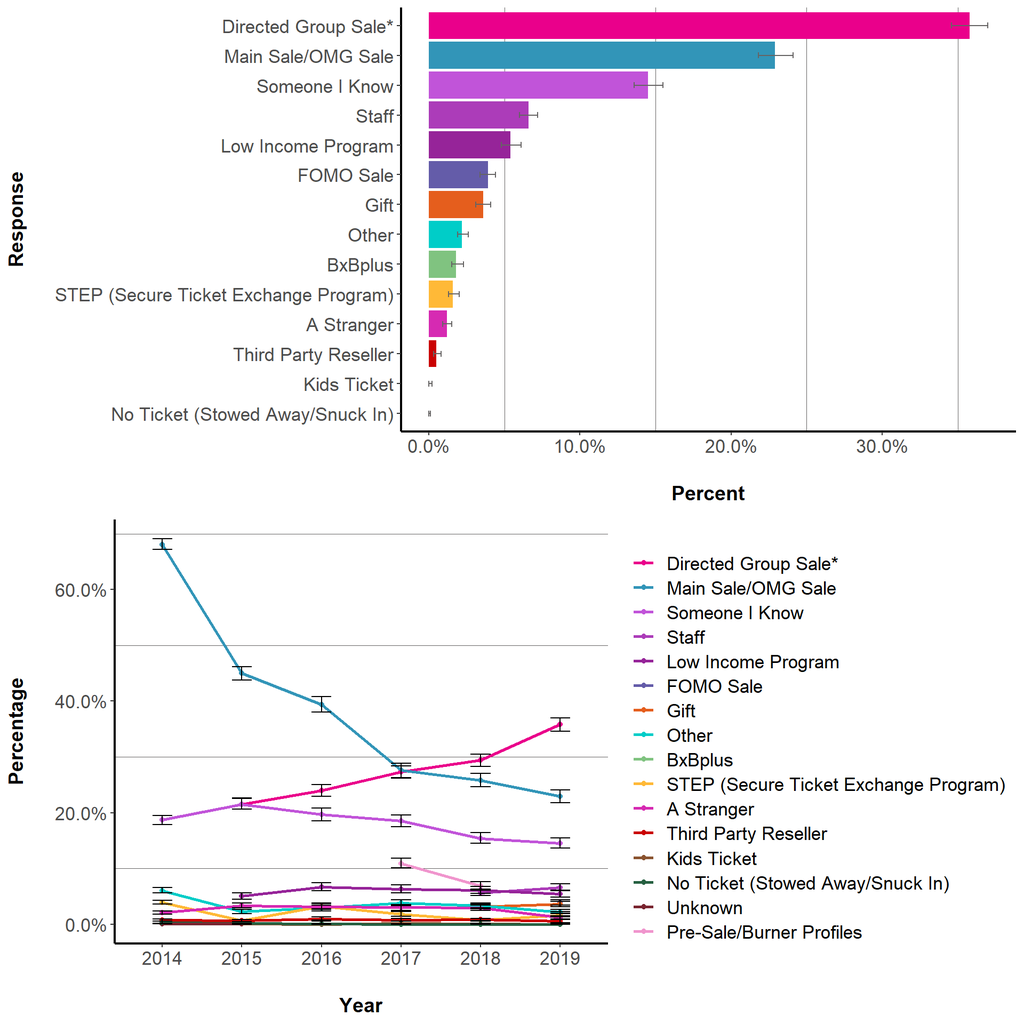

Error bars indicate the upper and lower bounds of the 95% confidence intervals.

* "Directed Group Sale" refers to ticket sales for theme camps, art projects, mutant vehicles, or staff/volunteers.

|  | 2014 Percent | 2014 MoE +/- % |  | 2015 Percent | 2015 MoE +/- % |  | 2016 Percent | 2016 MoE +/- % |  | 2017 Percent | 2017 MoE +/- % |  | 2018 Percent | 2018 MoE +/- % |  | 2019 Percent | 2019 MoE +/- % |
| --- | --- | --- | --- | --- | --- | --- | --- | --- | --- | --- | --- | --- | --- | --- | --- | --- | --- |
| Directed Group Sale* | NA | NA |  | 21.5 | 1.0 |  | 24.0 | 1.0 |  | 27.3 | 1.2 |  | 29.4 | 1.2 |  | 35.8 | 1.2 |
| Main Sale/OMG Sale | 68.1 | 1.0 |  | 45.0 | 1.2 |  | 39.4 | 1.4 |  | 27.6 | 1.2 |  | 25.8 | 1.2 |  | 22.9 | 1.2 |
| Someone I Know | 18.7 | 0.8 |  | 21.5 | 1.0 |  | 19.7 | 1.2 |  | 18.5 | 1.0 |  | 15.4 | 1.0 |  | 14.5 | 1.0 |
| Staff | NA | NA |  | NA | NA |  | NA | NA |  | NA | NA |  | 5.6 | 0.6 |  | 6.6 | 0.6 |
| Low Income Program | NA | NA |  | 5.0 | 0.6 |  | 6.7 | 0.8 |  | 6.3 | 0.6 |  | 6.1 | 0.6 |  | 5.4 | 0.6 |
| FOMO Sale | NA | NA |  | NA | NA |  | NA | NA |  | NA | NA |  | NA | NA |  | 3.9 | 0.6 |
| Gift | NA | NA |  | NA | NA |  | NA | NA |  | NA | NA |  | 3.1 | 0.4 |  | 3.6 | 0.4 |
| Other | 6.0 | 0.6 |  | 2.3 | 0.4 |  | 2.9 | 0.4 |  | 3.8 | 0.6 |  | 3.3 | 0.4 |  | 2.2 | 0.4 |
| BxBplus | NA | NA |  | NA | NA |  | NA | NA |  | NA | NA |  | NA | NA |  | 1.8 | 0.4 |
| STEP (Secure Ticket Exchange Program) | 3.9 | 0.4 |  | 0.6 | 0.2 |  | 3.2 | 0.6 |  | 1.8 | 0.4 |  | 0.7 | 0.2 |  | 1.6 | 0.4 |
| A Stranger | 2.1 | 0.2 |  | 3.3 | 0.4 |  | 3.1 | 0.6 |  | 3.0 | 0.6 |  | 2.9 | 0.4 |  | 1.2 | 0.4 |
| Third Party Reseller | 0.7 | 0.2 |  | 0.6 | 0.2 |  | 0.9 | 0.2 |  | 0.7 | 0.2 |  | 0.8 | 0.2 |  | 0.5 | 0.2 |
| Kids Ticket | NA | NA |  | 0.1 | 0.0 |  | 0.0 | 0.0 |  | 0.2 | 0.2 |  | NA | NA |  | 0.0 | 0.0 |
| No Ticket (Stowed Away/Snuck In) | 0.3 | 0.2 |  | NA | NA |  | 0.1 | 0.2 |  | 0.0 | 0.0 |  | 0.0 | 0.0 |  | 0.0 | 0.0 |
| Unknown | 0.1 | 0.0 |  | 0.1 | 0.0 |  | NA | NA |  | NA | NA |  | NA | NA |  | NA | NA |
| Pre-Sale/Burner Profiles | NA | NA |  | NA | NA |  | NA | NA |  | 10.9 | 0.8 |  | 6.9 | 0.6 |  | NA | NA |

## Participant Expenses

# Burning Man Ticket Cost

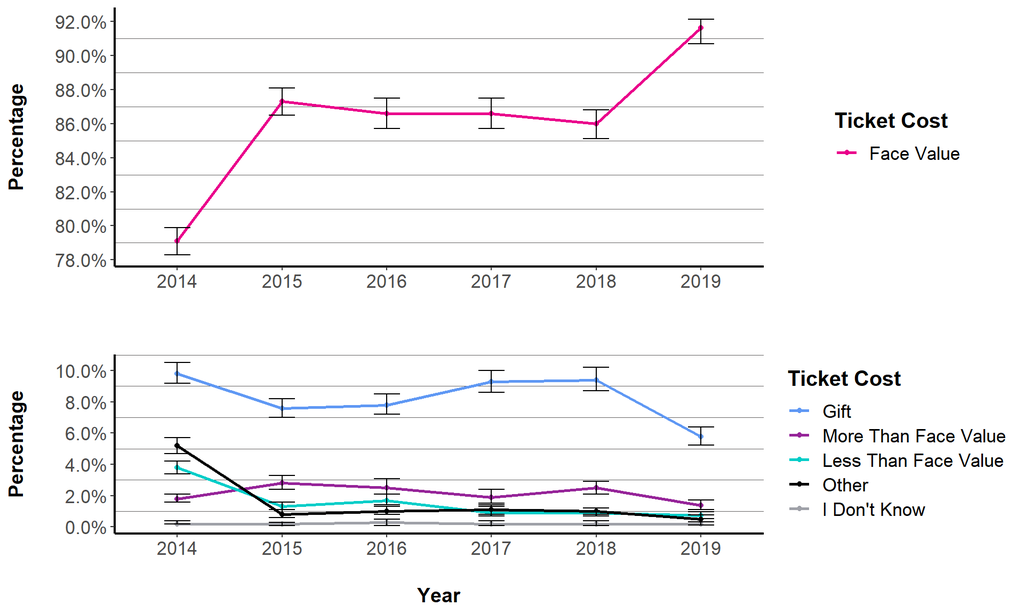

Error bars indicate the upper and lower bounds of the 95% confidence intervals.

|  | 2014 Percent | 2014 MoE +/- % |  | 2015 Percent | 2015 MoE +/- % |  | 2016 Percent | 2016 MoE +/- % |  | 2017 Percent | 2017 MoE +/- % |  | 2018 Percent | 2018 MoE +/- % |  | 2019 Percent | 2019 MoE +/- % |
| --- | --- | --- | --- | --- | --- | --- | --- | --- | --- | --- | --- | --- | --- | --- | --- | --- | --- |
| Face Value | 79.1 | 0.8 |  | 87.3 | 0.8 |  | 86.6 | 1.0 |  | 86.6 | 1.0 |  | 86.0 | 0.8 |  | 91.6 | 0.7 |
| Gift | 9.8 | 0.6 |  | 7.6 | 0.6 |  | 7.8 | 0.6 |  | 9.3 | 0.8 |  | 9.4 | 0.8 |  | 5.8 | 0.6 |
| More Than Face Value | 1.8 | 0.2 |  | 2.8 | 0.4 |  | 2.5 | 0.4 |  | 1.9 | 0.4 |  | 2.5 | 0.4 |  | 1.4 | 0.3 |
| Less Than Face Value | 3.8 | 0.4 |  | 1.3 | 0.2 |  | 1.7 | 0.4 |  | 0.9 | 0.2 |  | 0.9 | 0.2 |  | 0.7 | 0.2 |
| Other | 5.2 | 0.4 |  | 0.8 | 0.2 |  | 1.0 | 0.2 |  | 1.1 | 0.2 |  | 1.0 | 0.2 |  | 0.5 | 0.2 |
| I Don’t Know | 0.2 | 0.2 |  | 0.2 | 0.0 |  | 0.3 | 0.2 |  | 0.2 | 0.2 |  | 0.2 | 0.2 |  | 0.2 | 0.1 |

## Participant Expenses

### Spending for Burning Man

| Year | 2014* | 2015 | 2016 | 2017 | 2018 | 2019 |
| --- | --- | --- | --- | --- | --- | --- |
| Median | $1,300 | $1,500 | $1,500 | $1,500 | $1,500 | $1,650 |
| 80th Percentile | $2,500 | $2,600 | $3,000 | $3,000 | $3,000 | $3,000 |

* The 2014 online survey asked about spending ranges, but did not ask for total amount spent, so percentile data for 2014 was estimated differently than for 2015-18.

## Participant Expenses

# Spending Ranges for Burning Man*

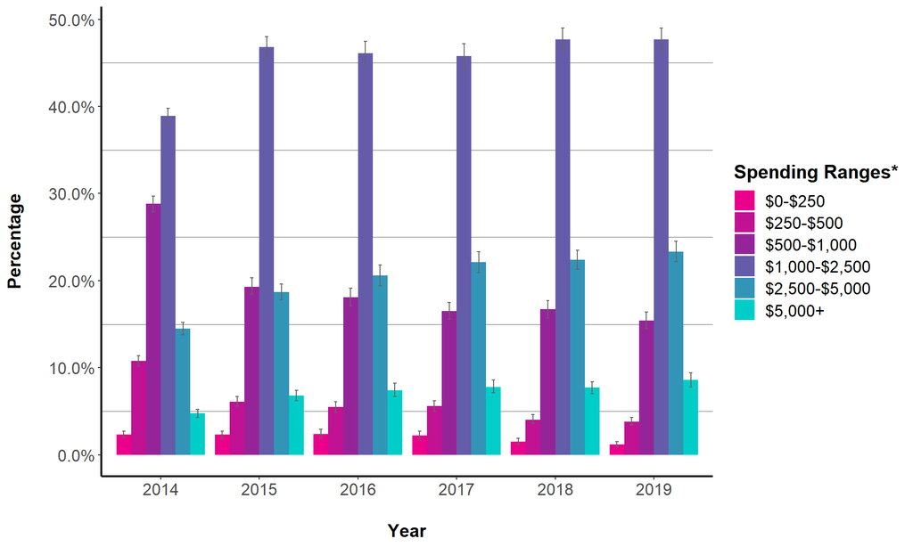

Error bars indicate the upper and lower bounds of the 95% confidence intervals.

* The exact wording of the question in the online survey was, "How much did you spend this year to go to Black Rock City and return, including fuel, camp dues, food, lodging, airfare, supplies, etc. (but not including your ticket to the event)? If you shared expenses with a group, only include the portion of expenses that you contributed. Give your best estimate in USD."

|  | 2014 Percent | 2014 MoE +/- % |  | 2015 Percent | 2015 MoE +/- % |  | 2016 Percent | 2016 MoE +/- % |  | 2017 Percent | 2017 MoE +/- % |  | 2018 Percent | 2018 MoE +/- % |  | 2019 Percent | 2019 MoE +/- % |
| --- | --- | --- | --- | --- | --- | --- | --- | --- | --- | --- | --- | --- | --- | --- | --- | --- | --- |
| $0-$250 | 2.3 | 0.4 |  | 2.3 | 0.4 |  | 2.4 | 0.4 |  | 2.2 | 0.4 |  | 1.5 | 0.4 |  | 1.2 | 0.2 |
| $250-$500 | 10.8 | 0.6 |  | 6.1 | 0.6 |  | 5.5 | 0.6 |  | 5.6 | 0.6 |  | 4.0 | 0.6 |  | 3.8 | 0.4 |
| $500-$1,000 | 28.8 | 1.0 |  | 19.3 | 1.0 |  | 18.1 | 1.0 |  | 16.5 | 1.0 |  | 16.7 | 1.0 |  | 15.4 | 1.0 |
| $1,000-$2,500 | 38.9 | 1.0 |  | 46.8 | 1.2 |  | 46.1 | 1.4 |  | 45.8 | 1.4 |  | 47.7 | 1.4 |  | 47.7 | 1.4 |
| $2,500-$5,000 | 14.5 | 0.8 |  | 18.7 | 1.0 |  | 20.6 | 1.2 |  | 22.1 | 1.2 |  | 22.4 | 1.2 |  | 23.3 | 1.2 |
| $5,000+ | 4.8 | 0.4 |  | 6.8 | 0.6 |  | 7.4 | 0.8 |  | 7.8 | 0.8 |  | 7.7 | 0.8 |  | 8.6 | 0.8 |

## Impacts on Nevada State

# Spending Ranges for Burning Man in Nevada State

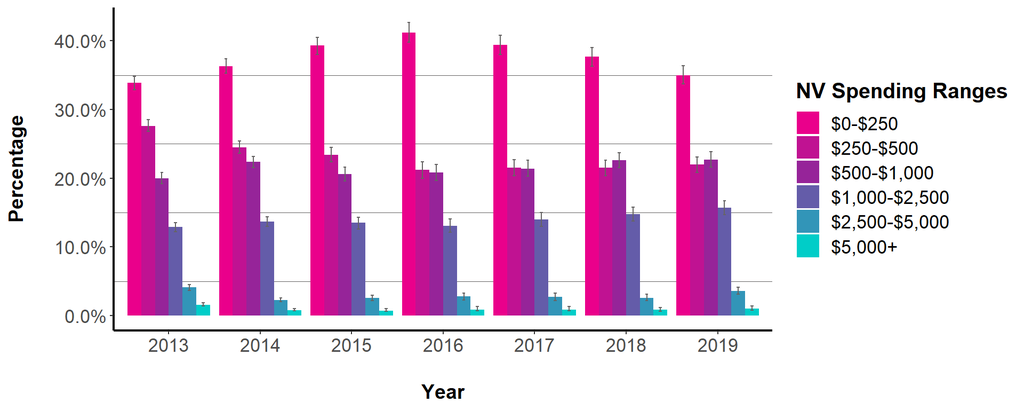

Error bars indicate the upper and lower bounds of the 95% confidence intervals.

|  | 2013 Percent | 2013 MoE +/- % |  | 2014 Percent | 2014 MoE +/- % |  | 2015 Percent | 2015 MoE +/- % |  | 2016 Percent | 2016 MoE +/- % |  | 2017 Percent | 2017 MoE +/- % |  | 2018 Percent | 2018 MoE +/- % |  | 2019 Percent | 2019 MoE +/- % |
| --- | --- | --- | --- | --- | --- | --- | --- | --- | --- | --- | --- | --- | --- | --- | --- | --- | --- | --- | --- | --- |
| $0-$250 | 33.9 | 1.0 |  | 36.3 | 1.0 |  | 39.3 | 1.2 |  | 41.2 | 1.4 |  | 39.4 | 1.4 |  | 37.7 | 1.4 |  | 35.0 | 1.4 |
| $250-$500 | 27.6 | 0.8 |  | 24.5 | 1.0 |  | 23.4 | 1.0 |  | 21.2 | 1.2 |  | 21.5 | 1.2 |  | 21.5 | 1.2 |  | 22.0 | 1.2 |
| $500-$1,000 | 20.0 | 0.8 |  | 22.4 | 0.8 |  | 20.6 | 1.0 |  | 20.8 | 1.2 |  | 21.4 | 1.2 |  | 22.6 | 1.2 |  | 22.7 | 1.2 |
| $1,000-$2,500 | 12.9 | 0.6 |  | 13.7 | 0.8 |  | 13.5 | 0.8 |  | 13.1 | 1.0 |  | 14.0 | 1.0 |  | 14.8 | 1.0 |  | 15.7 | 1.0 |
| $2,500-$5,000 | 4.1 | 0.4 |  | 2.3 | 0.4 |  | 2.6 | 0.4 |  | 2.8 | 0.6 |  | 2.7 | 0.6 |  | 2.6 | 0.4 |  | 3.6 | 0.6 |
| $5,000+ | 1.6 | 0.2 |  | 0.8 | 0.2 |  | 0.7 | 0.2 |  | 0.9 | 0.4 |  | 0.9 | 0.2 |  | 0.9 | 0.2 |  | 1.0 | 0.2 |

## Impacts on Nevada State

# Spending in Nevada State for Burning Man, by Category (Average USD)

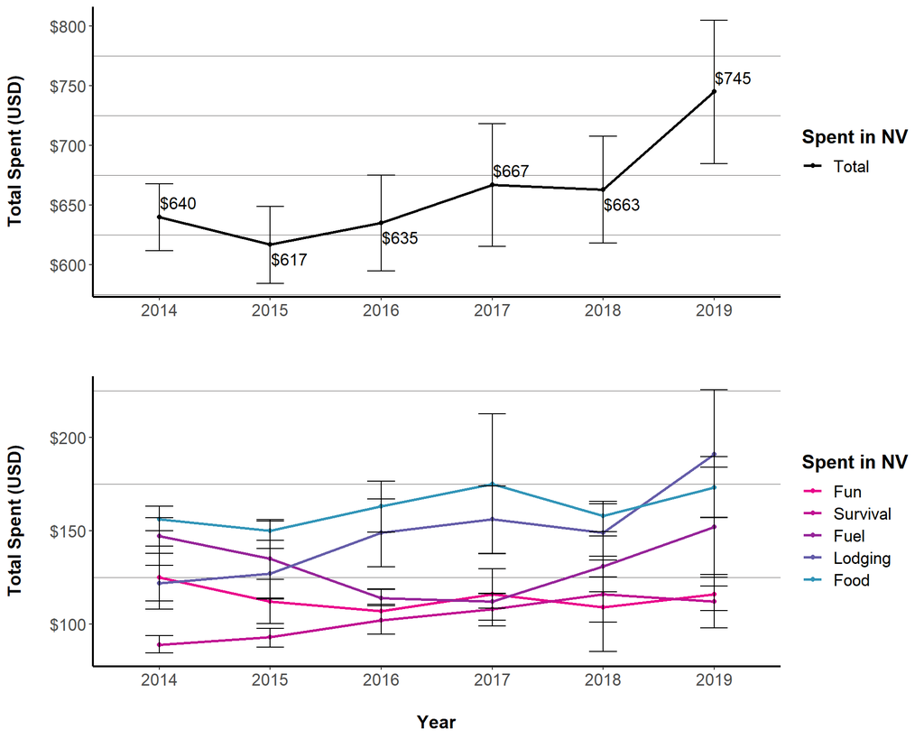

Error bars indicate the upper and lower bounds of the 95% confidence intervals.

[output not shown]

## Impacts on Nevada State

### NV Cities and Communities Visited en Route to/from Black Rock City*

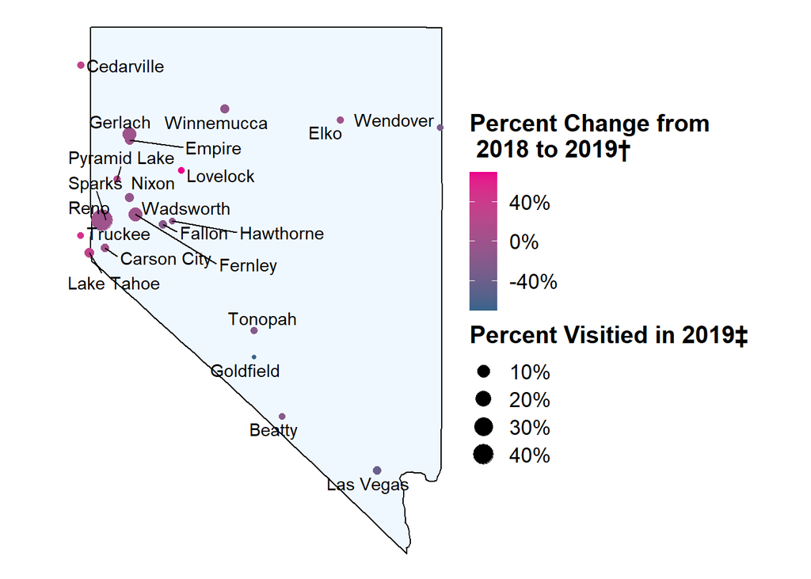

|  | 2018 Percent | 2018 MoE +/- % |  | 2019 Percent | 2019 MoE +/- % |
| --- | --- | --- | --- | --- | --- |
| Reno | 44.9 | 1.4 |  | 45.2 | 1.4 |
| Gerlach | 13.0 | 1.0 |  | 13.2 | 1.0 |
| Fernley | 12.5 | 0.8 |  | 13.1 | 0.8 |
| Sparks | 7.1 | 0.6 |  | 7.5 | 0.8 |
| Empire | 4.2 | 0.6 |  | 4.3 | 0.6 |
| Lake Tahoe | 3.1 | 0.6 |  | 4.1 | 0.6 |
| Winnemucca | 3.4 | 0.4 |  | 3.1 | 0.4 |
| Nixon | 3.4 | 0.4 |  | 3.0 | 0.4 |
| Las Vegas | 4.2 | 0.6 |  | 2.5 | 0.4 |
| Carson City | 2.4 | 0.4 |  | 2.3 | 0.4 |
| Fallon | 2.6 | 0.4 |  | 2.2 | 0.4 |
| Wadsworth | 2.2 | 0.4 |  | 1.9 | 0.4 |
| Pyramid Lake | 1.1 | 0.2 |  | 1.3 | 0.2 |
| Cedarville | 1.0 | 0.2 |  | 1.3 | 0.2 |
| Tonopah | 1.6 | 0.4 |  | 1.3 | 0.2 |
| Elko | 1.1 | 0.4 |  | 1.1 | 0.2 |
| Lovelock | 0.4 | 0.2 |  | 0.7 | 0.2 |
| Hawthorne | 0.8 | 0.2 |  | 0.7 | 0.2 |
| Beatty | 0.9 | 0.2 |  | 0.7 | 0.2 |
| Wendover | 0.8 | 0.2 |  | 0.6 | 0.2 |
| Truckee | 0.4 | 0.2 |  | 0.6 | 0.2 |
| Goldfield | 0.3 | 0.2 |  | 0.1 | 0.0 |

## Impacts on Nevada State

# Intent to Return to the Black Rock Desert Outside of Burning Man

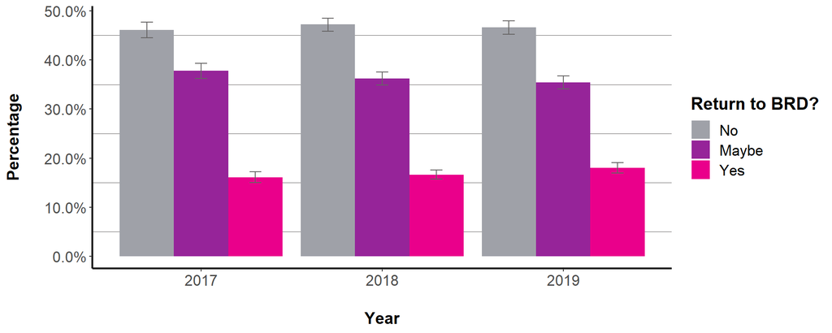

Error bars indicate the upper and lower bounds of the 95% confidence intervals.

|  | 2017 Percent | 2017 MoE +/- % |  | 2018 Percent | 2018 MoE +/- % |  | 2019 Percent | 2019 MoE +/- % |
| --- | --- | --- | --- | --- | --- | --- | --- | --- |
| No | 46.1 | 1.6 |  | 47.2 | 1.4 |  | 46.6 | 1.4 |
| Maybe | 37.8 | 1.6 |  | 36.2 | 1.4 |  | 35.4 | 1.4 |
| Yes | 16.1 | 1.2 |  | 16.6 | 1.0 |  | 18.0 | 1.0 |

## Impacts on Nevada State

# Recreational Activities on Public Lands Within 30 Miles of Black Rock City en Route To/From Burning Man*

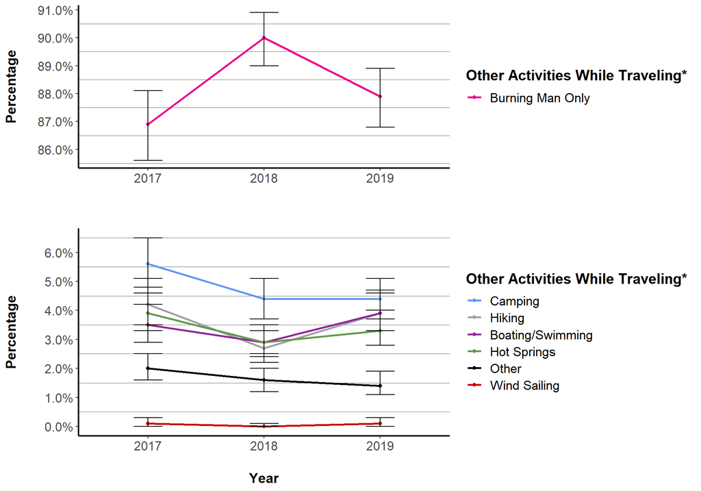

Error bars indicate the upper and lower bounds of the 95% confidence intervals.

* Participants selected all option(s) that applied.

|  | 2017 Percent | 2017 MoE +/- % |  | 2018 Percent | 2018 MoE +/- % |  | 2019 Percent | 2019 MoE +/- % |
| --- | --- | --- | --- | --- | --- | --- | --- | --- |
| Burning Man Only | 86.9 | 1.2 |  | 90.0 | 1.0 |  | 87.9 | 1.0 |
| Camping | 5.6 | 0.8 |  | 4.4 | 0.8 |  | 4.4 | 0.6 |
| Hiking | 4.2 | 0.8 |  | 2.7 | 0.6 |  | 3.9 | 0.6 |
| Boating/Swimming | 3.5 | 0.6 |  | 2.9 | 0.6 |  | 3.9 | 0.6 |
| Hot Springs | 3.9 | 0.6 |  | 2.9 | 0.6 |  | 3.3 | 0.6 |
| Other | 2.0 | 0.4 |  | 1.6 | 0.4 |  | 1.4 | 0.4 |
| Wind Sailing | 0.1 | 0.2 |  | 0.0 | 0.0 |  | 0.1 | 0.0 |

## Other Recreation

# Visits to Parks and/or Recreation Areas en Route to/from BRC*

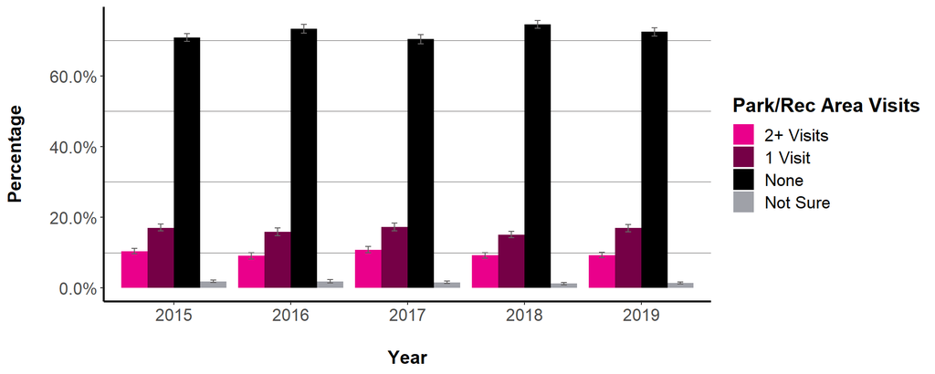

Error bars indicate the upper and lower bounds of the 95% confidence intervals.

* This question in the online survey specifically inquired about visits during "this year."

|  | 2015 Percent | 2015 MoE +/- % |  | 2016 Percent | 2016 MoE +/- % |  | 2017 Percent | 2017 MoE +/- % |  | 2018 Percent | 2018 MoE +/- % |  | 2019 Percent | 2019 MoE +/- % |
| --- | --- | --- | --- | --- | --- | --- | --- | --- | --- | --- | --- | --- | --- | --- |
| 2+ Visits | 10.4 | 0.8 |  | 9.1 | 0.8 |  | 10.8 | 1.0 |  | 9.2 | 0.8 |  | 9.2 | 0.8 |
| 1 Visit | 17.0 | 1.0 |  | 15.8 | 1.0 |  | 17.2 | 1.0 |  | 15.1 | 1.0 |  | 16.9 | 1.0 |
| None | 70.8 | 1.2 |  | 73.3 | 1.4 |  | 70.4 | 1.4 |  | 74.6 | 1.2 |  | 72.5 | 1.2 |
| Not Sure | 1.8 | 0.4 |  | 1.8 | 0.4 |  | 1.6 | 0.4 |  | 1.2 | 0.4 |  | 1.4 | 0.4 |

*The 2013 and 2014 online surveys included differently worded questions about park visits, so direct comparison is impossible. In 2013 and 2014 respectively, 68.8% (+/- 1.0) and 73.5% (+/- 0.9) of participants did not visit any parks or recreation areas, and 2.9% (+/- 0.4) and 1.7% (+/- 0.3) were not sure.*

**Next:** Transportation: Travel Dates, Length of Stay, and Ports of Travel